# Carte des variables environnementales finales

Boris Leroy

2024-05-26

Chargement des données

```r
library(sf)
```

```r
library(ggplot2)
library(terra)
fra <- st_read("data/fra.gpkg")
```

Reading layer `fra' from data source`C:_PNA_Corse.gpkg’ using driver `GPKG’ Simple feature collection with 1 feature and 168 fields Geometry type: MULTIPOLYGON Dimension: XY Bounding box: xmin: -61.79784 ymin: -21.37078 xmax: 55.8545 ymax: 51.08754 Geodetic CRS: WGS 84

```r
env_corse <- rast("data/env_corse_total_sync.tif")
```

# 1. Données climatiques : source de données CHELSA

## Description et méta-données

**Téléchargement :** www.chelsa-climate.org

**Intervalle temporel :** 1981-2010

**Type de données :** Raster

**Résolution initiale :** 0.0083333°

**Méta-données :** https://chelsa-climate.org/wp-admin/download-page/CHELSA_tech_specification_V2.pdf

**Références bibliographiques :**

- Brun, P., Zimmermann, N.E., Hari, C., Pellissier, L., Karger, D. (2022): Data from: CHELSA-BIOCLIM+ A novel set of global climate-related predictors at kilometre-resolution. *EnviDat*. https://doi.org/10.16904/envidat.332
- Karger D.N., Conrad, O., Böhner, J., Kawohl, T., Kreft, H., Soria-Auza, R.W., Zimmermann, N.E, Linder, H.P., Kessler, M. (2018): Data from: Climatologies at high resolution for the earth’s land surface areas. *EnviDat*. https://doi.org/10.16904/envidat.228.v2.1
- Karger, D.N., Conrad, O., Böhner, J., Kawohl, T., Kreft, H., Soria-Auza, R.W., Zimmermann, N.E., Linder, P., Kessler, M. (2017): Climatologies at high resolution for the Earth land surface areas. *Scientific Data*. 4 170122. https://doi.org/10.1038/sdata.2017.122
- Brun, P., Zimmermann, N.E., Hari, C., Pellissier, L., Karger, D.N. (preprint): Global climate-related predictors at kilometre resolution for the past and future. *Earth Syst. Sci. Data Discuss.* https://doi.org/10.5194/essd-2022-212

**Licence :** Creative Commons Zero - No Rights Reserved (CC0 1.0)

**Description des variables :** Les variables bioclimatiques (variables bio1 à bio19) sont décrites dans [Karger et al. 2017](https://doi.org/10.1038/sdata.2017.122). Les autres variables sont décrites dans [Brun et al. (2022)](https://doi.org/10.5194/essd-2022-212). La variable de température minimale de la saison estivale pour les chiroptères a été calculée à partir des valeurs mensuelles de température minimale pour les mois de mai à septembre.

## Illustration des variables

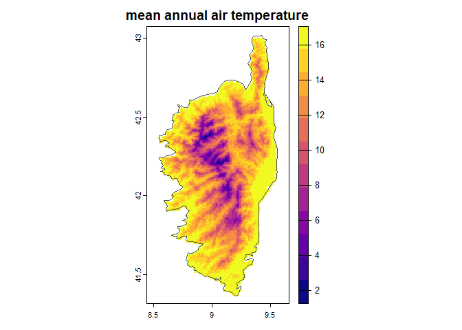

| vars | longname | unit | scale | offset | explanation |
| --- | --- | --- | --- | --- | --- |
| bio1 | mean annual air temperature | °C | 0.1 | -273.15 | mean annual daily mean air temperatures averaged over 1 year |

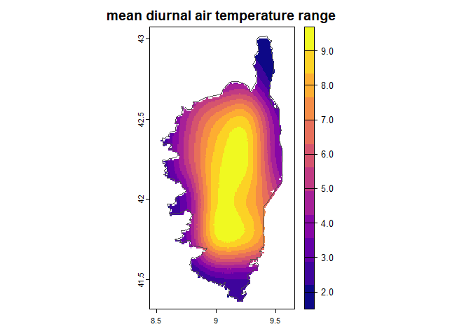

|  | vars | longname | unit | scale | offset | explanation |
| --- | --- | --- | --- | --- | --- | --- |
| 2 | bio2 | mean diurnal air temperature range | °C | 0.1 | 0 | mean diurnal range of temperatures averaged over 1 year |

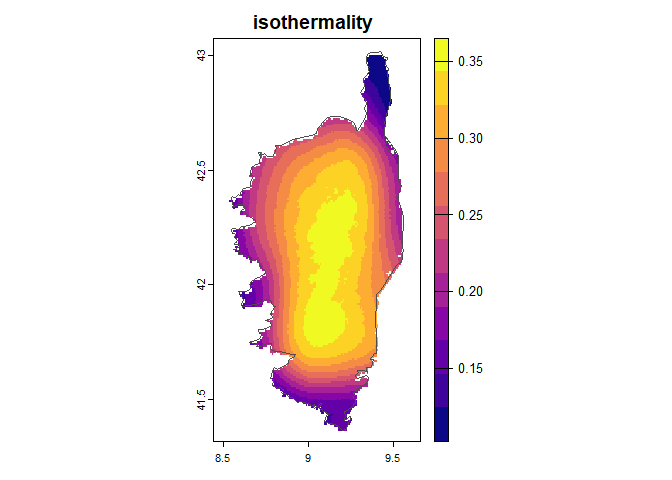

|  | vars | longname | unit | scale | offset | explanation |
| --- | --- | --- | --- | --- | --- | --- |
| 3 | bio3 | isothermality | °C | 0.1 | 0 | ratio of diurnal variation to annual variation in temperatures |

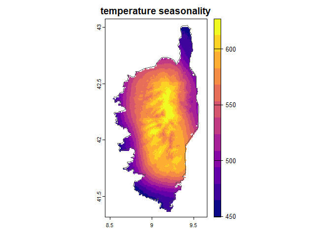

|  | vars | longname | unit | scale | offset | explanation |
| --- | --- | --- | --- | --- | --- | --- |
| 4 | bio4 | temperature seasonality | °C/100 | 0.1 | 0 | standard deviation of the monthly mean temperatures |

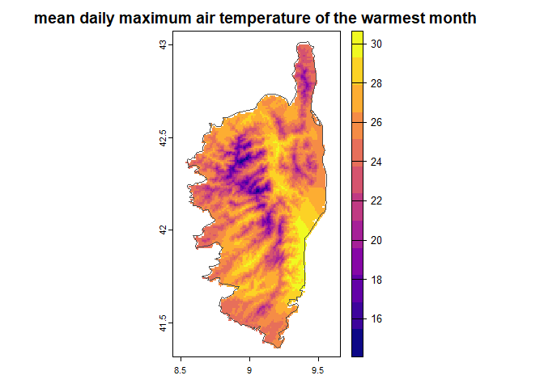

|  | vars | longname | unit | scale | offset | explanation |
| --- | --- | --- | --- | --- | --- | --- |
| 5 | bio5 | mean daily maximum air temperature of the warmest month | °C | 0.1 | -273.15 | The highest temperature of any monthly daily mean maximum temperature |

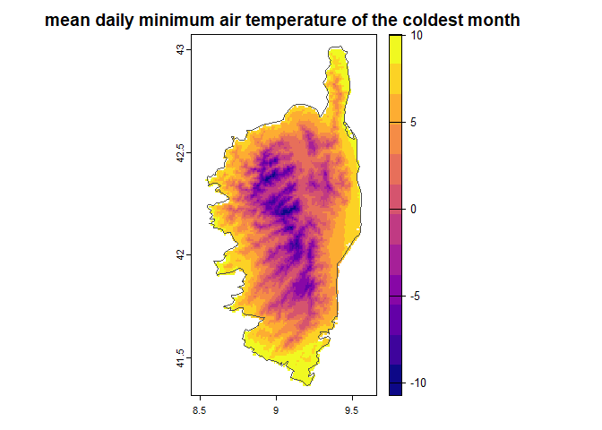

|  | vars | longname | unit | scale | offset | explanation |
| --- | --- | --- | --- | --- | --- | --- |
| 6 | bio6 | mean daily minimum air temperature of the coldest month | °C | 0.1 | -273.15 | The lowest temperature of any monthly daily mean maximum temperature |

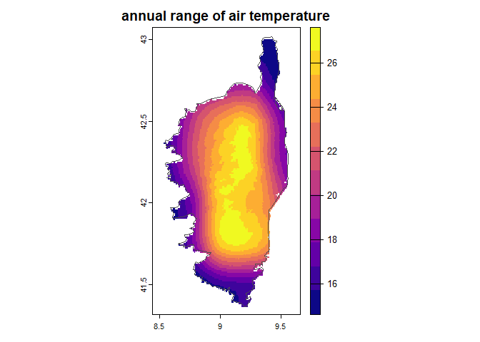

|  | vars | longname | unit | scale | offset | explanation |
| --- | --- | --- | --- | --- | --- | --- |
| 7 | bio7 | annual range of air temperature | °C | 0.1 | 0 | The difference between the Maximum Temperature of Warmest month and the Minimum Temperature of Coldest month |

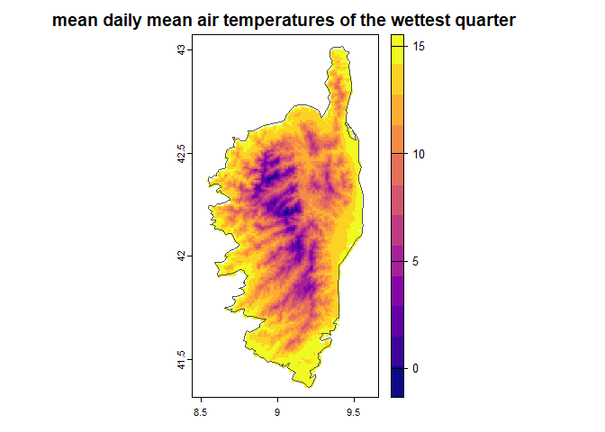

|  | vars | longname | unit | scale | offset | explanation |
| --- | --- | --- | --- | --- | --- | --- |
| 8 | bio8 | mean daily mean air temperatures of the wettest quarter | °C | 0.1 | -273.15 | The wettest quarter of the year is determined (to the nearest month) |

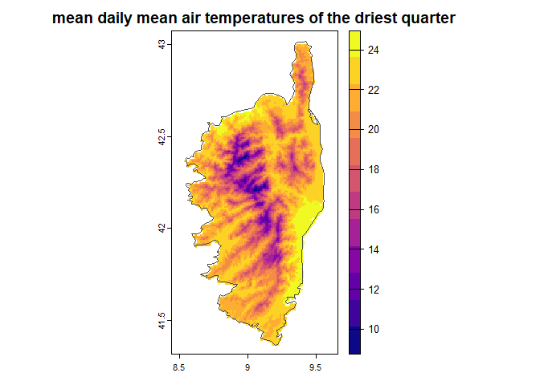

|  | vars | longname | unit | scale | offset | explanation |
| --- | --- | --- | --- | --- | --- | --- |
| 9 | bio9 | mean daily mean air temperatures of the driest quarter | °C | 0.1 | -273.15 | The driest quarter of the year is determined (to the nearest month) |

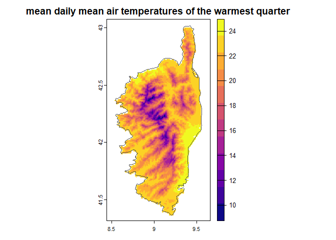

|  | vars | longname | unit | scale | offset | explanation |
| --- | --- | --- | --- | --- | --- | --- |
| 10 | bio10 | mean daily mean air temperatures of the warmest quarter | °C | 0.1 | -273.15 | The warmest quarter of the year is determined (to the nearest month) |

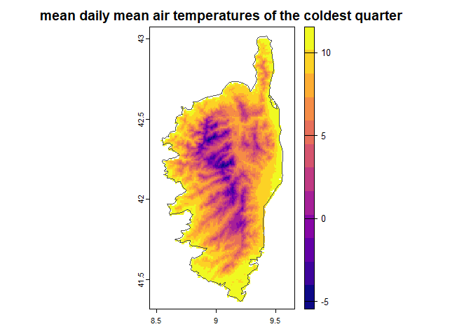

|  | vars | longname | unit | scale | offset | explanation |
| --- | --- | --- | --- | --- | --- | --- |
| 11 | bio11 | mean daily mean air temperatures of the coldest quarter | °C | 0.1 | -273.15 | The coldest quarter of the year is determined (to the nearest month) |

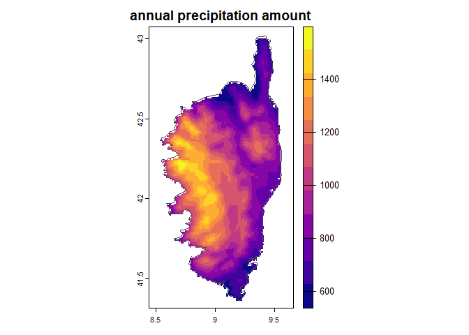

|  | vars | longname | unit | scale | offset | explanation |
| --- | --- | --- | --- | --- | --- | --- |
| 12 | bio12 | annual precipitation amount | kg m-2 year-1 | 0.1 | 0 | Accumulated precipitation amount over 1 year |

[42 more figures not shown]

|  | vars | longname | unit | scale | offset | explanation |
| --- | --- | --- | --- | --- | --- | --- |
| 54 | vpd_range | Annual range of monthly vapor pressure deficit | Pa | 0.1 | 0 | Difference between maximum and minimum monthly vapor pressure deficit |

```r
vars <- xlsx::read.xlsx("data/chelsa_variable_names.xlsx",
                  sheetIndex = 1)

for(i in 1:54){
    plot(env_corse[[i]],
         col = viridis::plasma(12),
         main = vars$longname[i])
    plot(st_geometry(fra), add = TRUE,
         border = grey(0.3))
    print(knitr::kable(vars[i, ]))
}
```

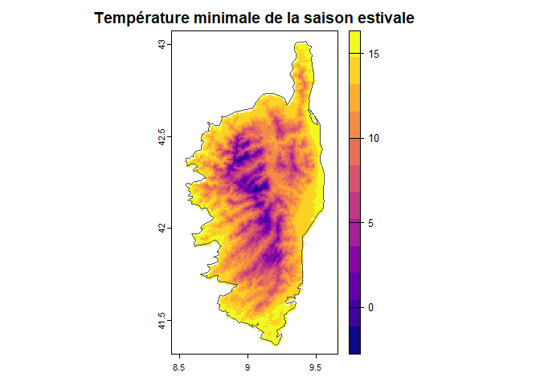

```r
plot(env_corse[["tasmin_chiro"]],
     col = viridis::plasma(12),
     main = "Température minimale de la saison estivale")
plot(st_geometry(fra), add = TRUE,
     border = grey(0.3))
```

# 2. Données routes

## Description et méta-données

**Téléchargement :** https://geoservices.ign.fr/bdcarto

**Intervalle temporel :** 2023

**Type de données :** Vectoriel

**Précision :** 1:50000 à 1:200000

**Méta-données :** https://geoservices.ign.fr/documentation/donnees/vecteur/bdcarto

**Références bibliographiques :**

**Licence :** licence ouverte Etalab 2.0

**Description des variables :** Distance à la plus proche cellule possédant une route en mètres

## Illustration des variables

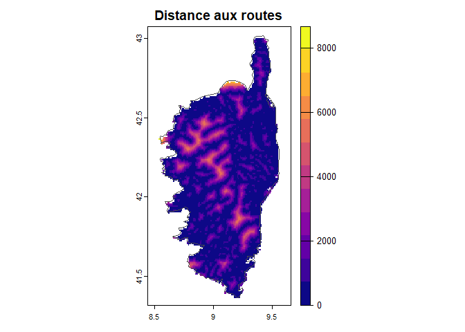

```r
plot(env_corse[["distance_routes"]],
     col = viridis::plasma(12),
     main = "Distance aux routes")
plot(st_geometry(fra), add = TRUE,
     border = grey(0.3))
```

# 3. Données hydrographiques

## Description et méta-données

**Téléchargement :** https://geoservices.ign.fr/bdtopo

**Intervalle temporel :** 2023

**Type de données :** Vectoriel

**Précision :** 1:2000 à 1:50000

**Méta-données :** https://geoservices.ign.fr/documentation/donnees/vecteur/bdtopo

**Références bibliographiques :**

**Licence :** licence ouverte Etalab 2.0

**Description des variables :** Les cours d’eau et les plans d’eau ont été fournis par la DREAL de Corse en résolution très fine (environ 0.0026 * 0.0017°), présence-absence par cellule. Ils ont été agrégés à la résolution des variables climatiques (0.0083333°) pour créer deux variables :

- la proportion de milieux d’eau douce dans chaque cellule de 0.0083333°
- la distance aux milieux d’eau douce, calculée comme la distance à la cellule la plus proche contenant au moins un milieu d’eau douce, en mètres

## Illustration des variables

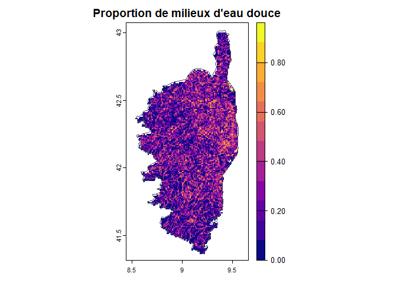

```r
plot(env_corse[["milieux_eaudouce"]],
     col = viridis::plasma(12),
     main = "Proportion de milieux d'eau douce")
plot(st_geometry(fra), add = TRUE,
     border = grey(0.3))
```

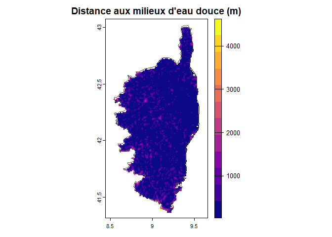

```r
plot(env_corse[["dist_moy_eau"]],
     col = viridis::plasma(12),
     main = "Distance aux milieux d'eau douce (m)")
plot(st_geometry(fra), add = TRUE,
     border = grey(0.3))
```

# 4. Zones humides

## Description et méta-données

**Téléchargement :** https://www.rhone-mediterranee.eaufrance.fr/sites/sierm/files/content/2022-03/Couches%20geo%20EHR%20et%20pressions_%20RMC.zip

**Intervalle temporel :**

**Type de données :** Vectoriel

**Résolution initiale :** 25m

**Méta-données :**

https://www.rhone-mediterranee.eaufrance.fr/preservation-et-restauration-des-milieuxzones-humides/la-politique-du-bassin-en-faveur-des-zones

**Références bibliographiques :**

CHAMBAUD F., BOUSCARY P. 2022. L’espace humide de référence : un nouveau référentiel en appui à la gestion des zones humides. Concept, méthode, résultats, utilisation. Collection Eau & Connaissance. Agence de l’eau Rhône Méditerranée Corse. 63p + annexes.

**Licence :** Non précisée, mais probablement libre accès Etalab 2.0 étant donné qu’il est basé sur des bases de données Etalab 2.0

**Description des variables :** Les données ont été fournies par la DREAL au format en résolution fine  
(0.002592892 * 0.00165493°), format présence par maille. Elles ont été agrégées à la résolution des variables climatiques (0.0083333°) pour créer deux variables :

- la proportion de zones humides dans chaque cellule de 0.0083333°
- la distance aux zones humides, calculée comme la distance à la cellule la plus proche contenant au moins une zone humide potentielle, en mètres

## Illustration des variables

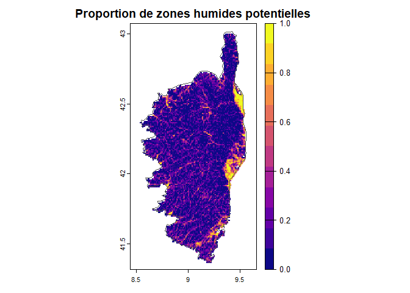

```r
plot(env_corse[["potentielles_zh"]],
     col = viridis::plasma(12),
     main = "Proportion de zones humides potentielles")
plot(st_geometry(fra), add = TRUE,
     border = grey(0.3))
```

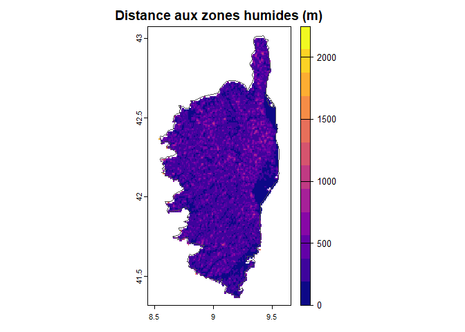

```r
plot(env_corse[["dist_moy_pzh"]],
     col = viridis::plasma(12),
     main = "Distance aux zones humides (m)")
plot(st_geometry(fra), add = TRUE,
     border = grey(0.3))
```

# 5. Occupation du sol Corine Land Cover

## Description et méta-données

**Téléchargement :** https://www.data.gouv.fr/fr/datasets/r/06aabb52-cfd9-46c7-bde6-f732d73af81f

**Intervalle temporel :** 2018

**Type de données :** Vectoriel

**Précision :** 1/100000

**Méta-données :** https://www.statistiques.developpement-durable.gouv.fr/corine-land-cover-0

**Références bibliographiques :**

https://www.statistiques.developpement-durable.gouv.fr/media/2459/download?inline

https://land.copernicus.eu/content/corine-land-cover-nomenclature-guidelines/docs/pdf/CLC2018_Nomenclature_illustrated_guide_20190510.pdf

**Licence :** Licence ouverte ETALAB

**Description des variables :** Les données vectorielles Corine Land Cover ont été transformées en rasters à la résolution des variables climatiques (0.0083333°) en calculant la proportion de chaque classe dans chaque pixel. Plusieurs variables spécifiques ont été créées ; cf. documents fournis dans références bibliographiques pour les codes :

- Le **bâti peu dense**, pour les chiroptères, en utilisant les classes 112 (tissu urbain discontinu) et 131 (extraction de matériaux) qui peuvent représenter des bâtiments isolés et des mines utilisables par les chiroptères
- Les **zones ouvertes**, pour la végétation des serpentinites, en utilisant les classes 332 (zones nues) et 333 (végétation clairsemée)
- Les **zones herbacées et arbustives**, pour l’habitat des papillons, en utilisant la classe 32 (Milieux à végétation arbustive et/ou herbacée)
- Les **milieux forestiers**, pour les amphibiens et les chiroptères, en utilisant la classe 31 (forêts)
- Les **surfaces agricoles cultivées**, en utilisant les classes 211 (terres arables), 221 (vignobles), 222 (vergers et petits fruits) et 223 (oliveraies)
- Les **zones artificialisées**, en utilisant les classes 111 (tissu urbain continu), 112 (tissu urbain discontinu), 121 (zones industrielles ou commerciales), 123 (zones portuaires), 124 (aéroports), 131 (extraction de matériaux), 132 (décharges)

D’autres variables ont été générées à partir de ces variables initiales :

- La **distance au bâti peu dense** (distance à la plus proche cellule avec du bâti peu dense) en mètres
- La **distance aux forêts** (distance à la plus proche cellule avec des forêts) en mètres
- L’**hétérogénéité du paysage**, calculée comme l’indice de simpson sur la proportion de chaque classe d’habitat naturel non marin dans chaque cellule (habitats des classes 1 et 5 exclus). Formule utilisée pour chaque cellule : $1 - \sum{x_i^2}$ où $x_i$ est la proportion de recouvrement de l’habitat *i* dans la cellule

## Illustration des variables

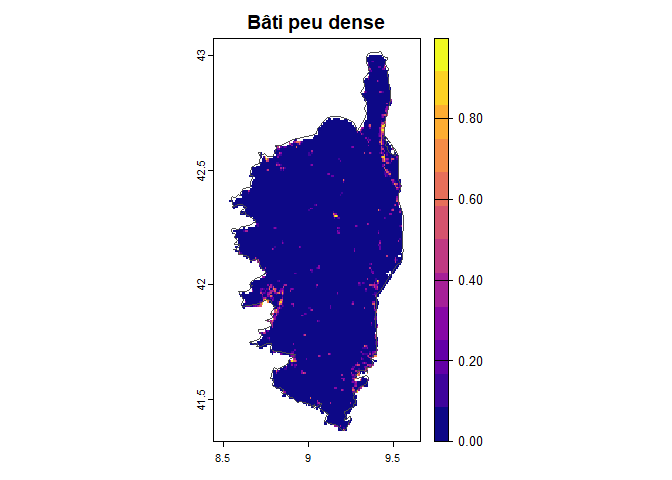

```r
plot(env_corse[["bati_peu_dense"]],
     col = viridis::plasma(12),
     main = "Bâti peu dense")
plot(st_geometry(fra), add = TRUE,
     border = grey(0.3))
```

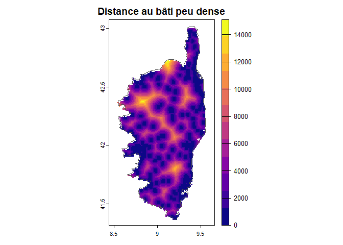

```r
plot(env_corse[["dist_bati_peu_dense"]],
     col = viridis::plasma(12),
     main = "Distance au bâti peu dense")
plot(st_geometry(fra), add = TRUE,
     border = grey(0.3))
```

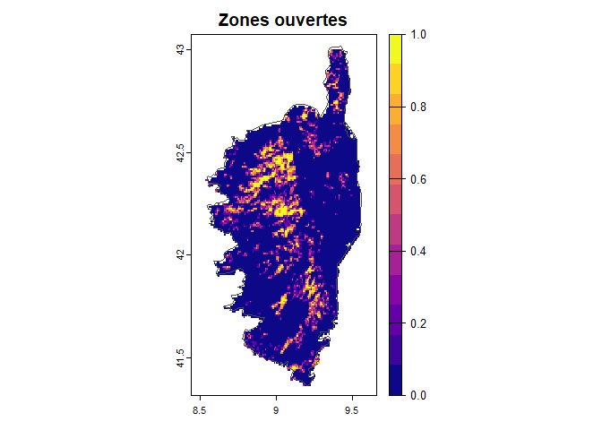

```r
plot(env_corse[["zones_ouvertes"]],
     col = viridis::plasma(12),
     main = "Zones ouvertes")
plot(st_geometry(fra), add = TRUE,
     border = grey(0.3))
```

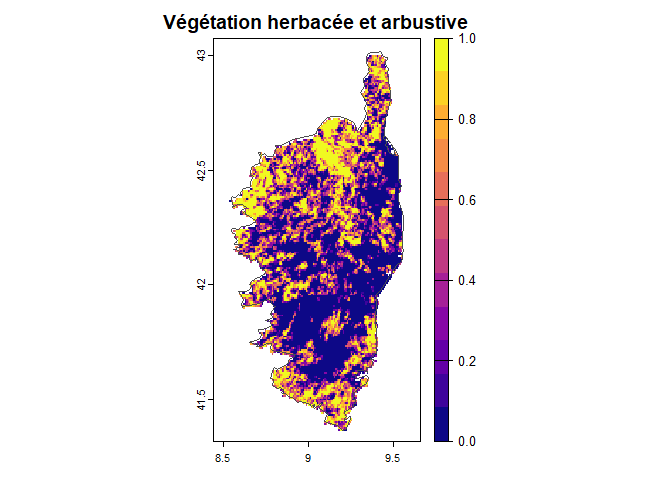

```r
plot(env_corse[["vege_herb"]],
     col = viridis::plasma(12),
     main = "Végétation herbacée et arbustive")
plot(st_geometry(fra), add = TRUE,
     border = grey(0.3))
```

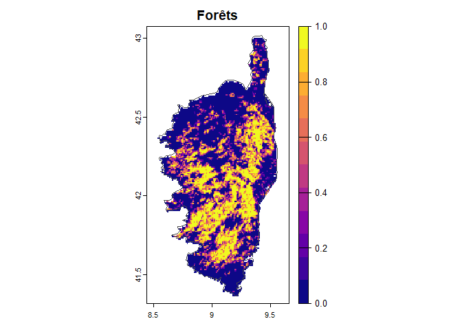

```r
plot(env_corse[["forets"]],
     col = viridis::plasma(12),
     main = "Forêts")
plot(st_geometry(fra), add = TRUE,
     border = grey(0.3))
```

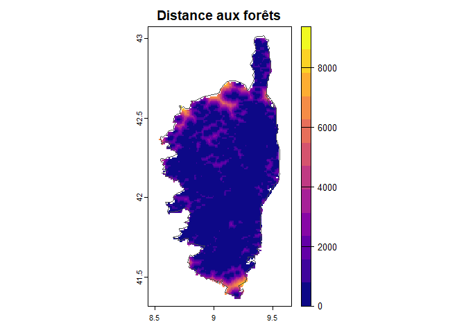

```r
plot(env_corse[["dist_forets"]],
     col = viridis::plasma(12),
     main = "Distance aux forêts")
plot(st_geometry(fra), add = TRUE,
     border = grey(0.3))
```

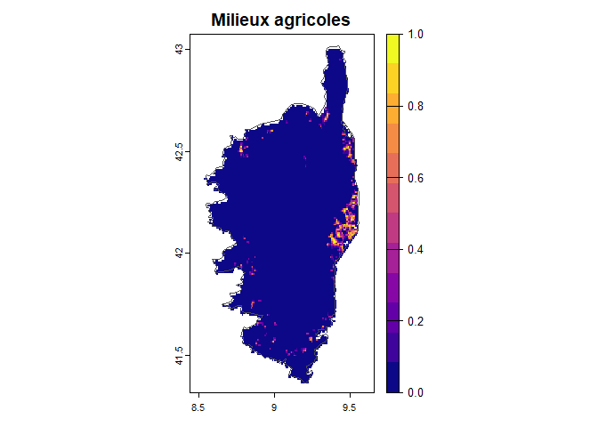

```r
plot(env_corse[["milieux_agri"]],
     col = viridis::plasma(12),
     main = "Milieux agricoles")
plot(st_geometry(fra), add = TRUE,
     border = grey(0.3))
```

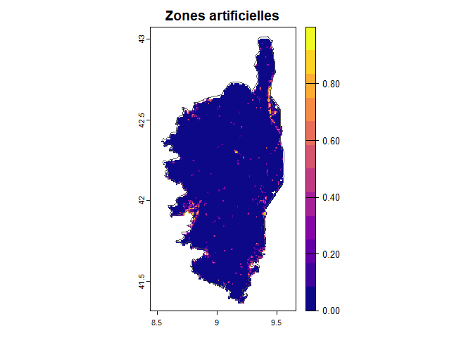

```r
plot(env_corse[["zones_artif"]],
     col = viridis::plasma(12),
     main = "Zones artificielles")
plot(st_geometry(fra), add = TRUE,
     border = grey(0.3))
```

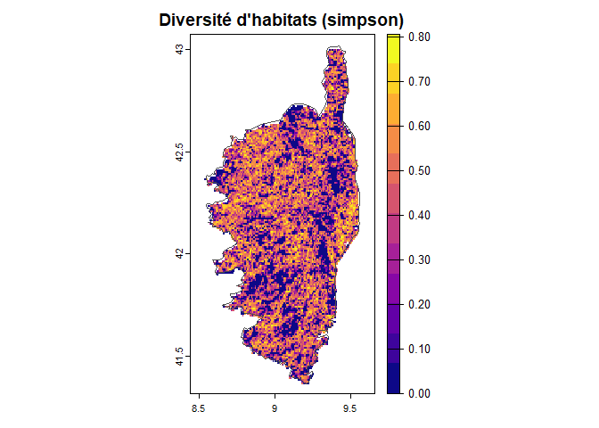

```r
plot(env_corse[["simpson_landscapediv"]],
     col = viridis::plasma(12),
     main = "Diversité d'habitats (simpson)")
plot(st_geometry(fra), add = TRUE,
     border = grey(0.3))
```

# 6. Pollution lumineuse

## Description et méta-données

**Téléchargement :** https://eogdata.mines.edu/nighttime_light/monthly/v10/

**Intervalle temporel :** 2013-2019

**Type de données :** raster

**Résolution initiale :** 0.00416667 * 0.00416667°

**Méta-données :** https://eogdata.mines.edu/products/vnl/

**Références bibliographiques :**

- C. D. Elvidge, K. Baugh, M. Zhizhin, F. C. Hsu, and T. Ghosh, “VIIRS night-time lights,” *International Journal of Remote Sensing*, vol. 38, pp. 5860–5879, 2017

**Licence :** CC-BY-4.0 This product was made utilizing (VIIRS night-time lights) data produced by the Earth Observation Group, Payne Institute for Public Policy, Colorado School of Mines.

**Description des variables :** Cette variable a été utilisée pour les chiroptères pour la période estivale. Les données de pollution lumineuse mensuelle moyenne ont été téléchargées pour les mois d’août et de septembre de 2013 à 2019 (seuls mois de la période estivale disponibles complètement pour toutes les années). Les données ont d’abord été agrégées à la résolution des variables climatiques (0.0083333°) par interpolation bilinéaire. La couche finale de pollution lumineuse a été obtenue en moyennant les valeurs sur les mois d’août et de septembre et entre toutes les années. La variable finale est une radiance moyenne en nW cm−2 sr−1.

## Illustration des variables

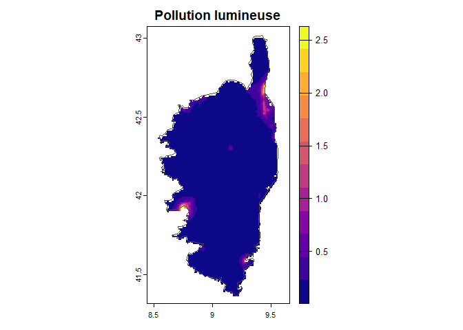

```r
plot(env_corse[["pollum"]],
     col = viridis::plasma(12),
     main = "Pollution lumineuse")
plot(st_geometry(fra), add = TRUE,
     border = grey(0.3))
```

# 7. Connectivité, intégrité biophysique et naturalité

## Description et méta-données

**Téléchargement :** https://uicn.fr/CartNat/CartNat_Donnees/

**Intervalle temporel :** 2000-2023

**Type de données :** raster

**Résolution initiale :** 20 * 20 m

**Méta-données :** https://uicn.fr/CartNat/CartNat_Donnees/Note_technique_m%c3%a9thodologique/Projet%20CARTNAT_note%20technique_2021.pdf https://uicn.fr/aires-protegees/wilderness/

**Références bibliographiques :** - Guetté A, Carruthers-Jones Jonathan, Carver Stephen J. 2021. Projet CARTNAT Cartographie de la Naturalité. Notice technique. Comité français de l’IUCN. https://uicn.fr/CartNat/CartNat_Donnees/Note_technique_m%c3%a9thodologique/Projet%20CARTNAT_note%20technique_2021.pdf

- Guetté A., Carruthers-Jones J., Godet L., Robin M. 2018. « Naturalité » : concepts et méthodes appliqués à la conservation de la nature. Cybergeo: European Journal of Geography [En ligne], document 856. URL : https://journals.openedition.org/cybergeo/29140#toc

**Licence :** CC-BY-NC

**Description des variables :** La naturalité est un indice composée de trois variables :

- **l’intégrité biophysique de l’occupation du sol**, qui traduit un état d’éloignement d’un paysage à ce qu’il serait sans transformation anthropique. Elle intègre notamment les notions de continuité temporelle de l’état boisé et de probabilité de non exploitation forestière, importantes pour plusieurs espèces/groupes d’espèces sujettes au Plan National d’Action. Cette variable est un indice relatif allant de 1 à 255, la valeur de 255 indiquant une forte intégrité.
- **la spontanéité des processus**, qui évalue le degré d’intervention humaine sur les dynamiques naturelles. Il s’agit ici d’un proxy d’influence humaine basé sur la distance aux routes et la densité de bâti. Il s’agit d’un indice variant de 1 à 15000, la valeur de 15000 indiquant une forte spontanéité. *Note* Etant donné que la variable “distance aux routes” est fortement utilisée pour contrôler le biais d’échantillonnage, cette variable spontanéité n’a pas été retenue pour le projet PNA Corse.
- **les continuités spatiales**, qui correspondent au degré de connectivité des paysages. Elle a été calculée avec un modèle dédié appelé “Omniscape” (cf. références ci-dessus). Il s’agit d’un indice variant de 1 à 400, la valeur de 400 indiquant une forte continuité

**L’indice de naturalité** final est la somme des trois variables, pondérées de manière égale, et représenté sur une échelle allant de 1 à 700, la valeur de 700 indiquant une forte naturalité.

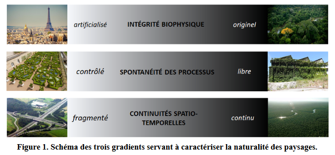